# Visualizing Time and Space

Author

Gargee Shah

Published

April 1, 2024

## Setup

If you have not installed the following packages, please install them before loading them.

```r
library(tidyverse)
library(readr)
library(readxl)
library(haven) #for loading other datafiles (SAS, STATA, SPSS, etc.)

#for plotting time
library(ggplot2) # if you have not installed this package, please install it.
library(lubridate)


#for plotting space
library(sp)
library(sf)
library(maps)
```

## Project Overview

In this project, I will practice the visualization skills with two datasets to capture the temporal and spatial patterns.

## Datasets

- Part 1. The UFO Sightings Data
- Part 2. The Hospital Location Data

Find the `_data` folder, then read the datasets using the correct R command.

## Part 1. The UFO Sightings Data

This data contains over 80,000 reports of UFO sightings over the last century in six major countries (and other places). You can learn more about this data by checking: https://www.kaggle.com/datasets/NUFORC/ufo-sightings.

1. **Read and Describe the Data**

   What is the dimension of the data? What do the columns mean? What is the unit of observation?

   *Dimensions of the data: Row - 88875 cols - 12*

   *The meaning of each column:*

   datetime: The date and time of the UFO sighting.

   city: The city where the UFO sighting was reported.

   state: The state where the UFO sighting was reported.

   country: The country where the UFO sighting was reported.

   shape: The shape of the UFO as described in the report.

   duration..seconds.: The duration of the UFO sighting in seconds.

   duration..hours.min.: The duration of the UFO sighting in hours and minutes.

   comments: Additional comments or details about the UFO sighting.

   date.posted: The date when the UFO sighting report was posted.

   latitude: The latitude coordinate of the UFO sighting location.

   longitude: The longitude coordinate of the UFO sighting location.

   *The unit of observation in this dataset is each individual UFO sighting event*

   ```r
   #type of your code/command here.
   ufo_data <- read.csv('complete_UFO.csv')
   print(names(ufo_data))
   ```

   ```
    [1] "datetime"             "city"                 "state"
    [4] "country"              "shape"                "duration..seconds."
    [7] "duration..hours.min." "comments"             "date.posted"
   [10] "latitude"             "longitude"            "X"
   ```

   ```r
   print(head(ufo_data))
   ```

   ```
       datetime                          city state country   shape
   1 11/11/1906                wien (austria)                 other
   2   1/2/1910             kirksville (near)    mo      us    disk
   3  5/28/1910                         solon    me      us unknown
   4   6/1/1910                   wills point    tx      us   cigar
   5  9/15/1914         meeting lake (canada)    ab         unknown
   6   4/5/1916 france (above; from aircraft)                 cigar
     duration..seconds. duration..hours.min.
   1              10800                  3 h
   2                120              minutes
   3                  0        don&#39t know
   4                120            2 minutes
   5                  0
   6                 60         about 1 min.
                                                                                                                                                comments
   1                                                              The oldest professional photo of a UFO object is from Wien observatory&#44 in 1906&#33
   2                                                                                                 Historical sighting (1903 - 1913) Northern Missouri
   3 entry in my great-grandmother&#39s diary&#44date 28 may 1910&#44refers to watching the comet zig-zaging in the sky&#44 followed by a zig-zag diagra
   4                                                                                                        Cigar shaped object moving from West to East
   5                      Night flying &quot;airplane&quot; with search lights observed on several occasions near Meeting Lake&#44 Alberta in late 1914.
   6                                                                                    ((NUFORC Note:  Possible hoax.  PD))  Saw 3 cigar shaped crafts.
     date.posted   latitude   longitude  X
   1  12/23/2002  48.208174   16.373819 NA
   2   9/15/2005 40.1947222  -92.583056 NA
   3   12/5/2001 44.9494444  -69.858889 NA
   4   4/16/2005 32.7091667  -96.008056 NA
   5    2/1/2007  55.170828 -118.837956 NA
   6    3/9/2004  46.227638    2.213749 NA
   ```

2. Please plot a temporal/time-series graph to present the following patterns. **You may need to subset or mutate the data for graphing.**

   (1) the total number of UFO sighting reports over the years (date_break = year).

   ```r
   #type of your code/command here.
      ufo_data$datetime <-
     as.Date(ufo_data$datetime, format = "%m/%d/%Y")

   ufo_data <- ufo_data |>
     mutate(Year = as.integer(format(datetime, "%Y")),# Extract the Year from datetime;
            Month = as.integer(format(datetime, "%m")),
            Day = as.integer(format(datetime, "%d")))

   head(ufo_data)
   ```

   |  | datetime | city | state | country | shape | duration..seconds. | duration..hours.min. | comments | date.posted | latitude | longitude | X | Year | Month | Day |
   | --- | --- | --- | --- | --- | --- | --- | --- | --- | --- | --- | --- | --- | --- | --- | --- |
   | 1 | 1906-11-11 | wien (austria) |  |  | other | 10800 | 3 h | The oldest professional photo of a UFO object is from Wien observatory&#44 in 1906&#33 | 12/23/2002 | 48.208174 | 16.373819 | NA | 1906 | 11 | 11 |
   | 2 | 1910-01-02 | kirksville (near) | mo | us | disk | 120 | minutes | Historical sighting (1903 - 1913) Northern Missouri | 9/15/2005 | 40.1947222 | -92.583056 | NA | 1910 | 1 | 2 |
   | 3 | 1910-05-28 | solon | me | us | unknown | 0 | don&#39t know | entry in my great-grandmother&#39s diary&#44date 28 may 1910&#44refers to watching the comet zig-zaging in the sky&#44 followed by a zig-zag diagra | 12/5/2001 | 44.9494444 | -69.858889 | NA | 1910 | 5 | 28 |
   | 4 | 1910-06-01 | wills point | tx | us | cigar | 120 | 2 minutes | Cigar shaped object moving from West to East | 4/16/2005 | 32.7091667 | -96.008056 | NA | 1910 | 6 | 1 |
   | 5 | 1914-09-15 | meeting lake (canada) | ab |  | unknown | 0 |  | Night flying &quot;airplane&quot; with search lights observed on several occasions near Meeting Lake&#44 Alberta in late 1914. | 2/1/2007 | 55.170828 | -118.837956 | NA | 1914 | 9 | 15 |
   | 6 | 1916-04-05 | france (above; from aircraft) |  |  | cigar | 60 | about 1 min. | ((NUFORC Note: Possible hoax. PD)) Saw 3 cigar shaped crafts. | 3/9/2004 | 46.227638 | 2.213749 | NA | 1916 | 4 | 5 |

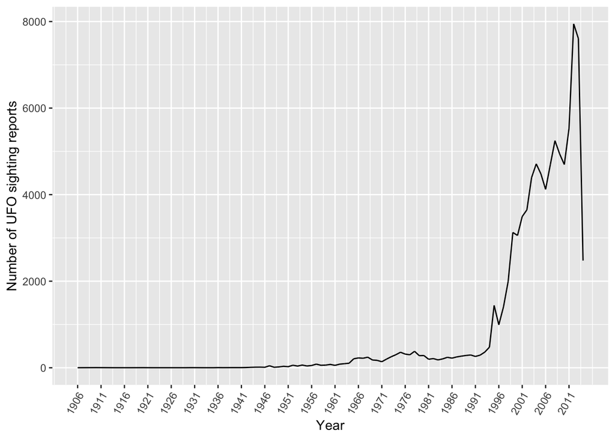

   ```r
     UFO_year <- ufo_data |>
     group_by(Year) |>
     mutate(YearSum = n())|>
     ggplot(aes(x = as.Date(Year), y = YearSum))+
     geom_line()+
     scale_x_continuous(breaks = seq(1906, 2015, by = 5))+
     theme(axis.text.x=element_text(angle = 60, hjust = 1))+
     xlab("Year")+
     ylab("Number of UFO sighting reports")

   UFO_year
   ```

   (2) the total number of UFO sighting reports by months between 2010-01-01 and 2014-01-01.

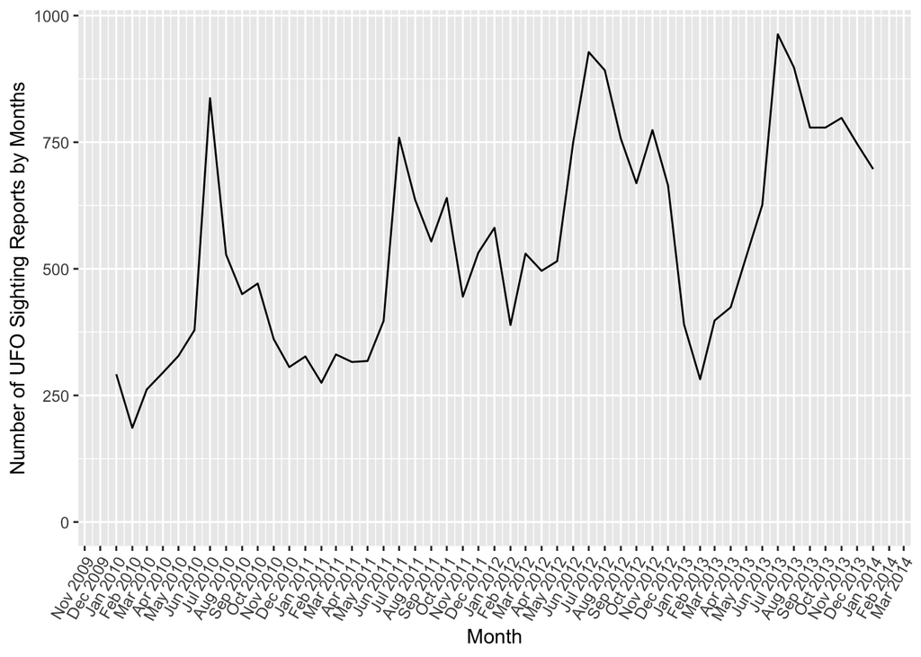

   ```r
    ufo_data |>
     group_by(Year, Month) |>
     summarise(MonthSum = n())|>
     mutate(UniqueMonth = make_date(Year, Month)) |>
     ggplot(aes(x = UniqueMonth, y = MonthSum))+
     geom_line()+
     scale_x_date(limits = as.Date(c("2010-01-01", "2014-01-01")), date_breaks = "1 month", date_labels = "%b %Y") +
     theme(axis.text.x=element_text(angle = 60, hjust = 1)) +
     xlab("Month")+
     ylab("Number of UFO Sighting Reports by Months")
   ```

3. Please write a paragraph describing the patterns you find on the two graphs above.

   **Answers:** From the total number of sightings over the years graph, we could see that the graph is left skewed meaning maximum data lies on the right side of the plot. Hence, we can conclude that the number of UFO sightings increases from 2000. Moreover, we see that UFO sighting reports significantly increases after 1995. Further, there was huge increase after 2010. The possible reasons could be due to development of mass media, advancement in internet, mobile devices etc. making normal individual to report such sightings.

   *Now, looking at number of ufo sightings vs months plot is that it follows almost normal/bell curve per year, i.e., the maximum sighting are reported during month of June, July and August for each year (one possible reason is that this is stargazing season in Northern Hemisphere) and it was lowest in the month of February for each year. Also, the monthly plot of year 2012 and 2013 have higher monthly distribution then years 2010 and 2011, explaining the highest overall count among all year.*

   *Overall, both graphs highlight the temporal patterns and fluctuations in UFO sighting reports, offering intriguing insights into the dynamics of UFO phenomena over time and within specific timeframes.*

## Part 2. The Hospital Location Data

This data contains the locations of hospitals in the United States. You can learn more about this data by checking: https://www.kaggle.com/datasets/andrewmvd/us-hospital-locations

1. **Read and Describe the Data**

   What is the dimension of the data? What do the columns mean? What is the unit of observation?

   *Dimensions of the data: Row - 7596 cols - 15*

   *Each column represents-*

   ID: Unique identifier for each hospital.

   NAME: Name of the hospital.

   ADDRESS: Street address of the hospital.

   CITY: City where the hospital is located.

   STATE: State where the hospital is located.

   ZIP: ZIP code of the hospital’s location.

   TYPE: Type of hospital (e.g., General Acute Care).

   STATUS: Status of the hospital (e.g., Open, Closed).

   POPULATION: Population served by the hospital.

   COUNTY: County where the hospital is located.

   COUNTRY: Country where the hospital is located.

   LATITUDE: Latitude coordinate of the hospital’s location.

   LONGITUDE: Longitude coordinate of the hospital’s location.

   OWNER: Owner of the hospital.

   BEDS: Number of beds available in the hospital.

   *The unit of observation in this dataset is each row, which represents a different hospital.*

   ```r
   #type of your code/command here.
   hospital_data <- read.csv('us_hospital_locations.csv')
   dim(hospital_data)
   ```

   ```
   [1] 7596   15
   ```

   ```r
   print(names(hospital_data))
   ```

   ```
    [1] "ID"         "NAME"       "ADDRESS"    "CITY"       "STATE"
    [6] "ZIP"        "TYPE"       "STATUS"     "POPULATION" "COUNTY"
   [11] "COUNTRY"    "LATITUDE"   "LONGITUDE"  "OWNER"      "BEDS"
   ```

   ```r
   print(head(hospital_data))
   ```

   ```
           ID                                               NAME
   1  5793230                    CENTRAL VALLEY GENERAL HOSPITAL
   2 53391362 LOS ROBLES HOSPITAL & MEDICAL CENTER - EAST CAMPUS
   3 11190023                  EAST LOS ANGELES DOCTORS HOSPITAL
   4 17090028          SOUTHERN CALIFORNIA HOSPITAL AT HOLLYWOOD
   5 23691706                      KINDRED HOSPITAL BALDWIN PARK
   6 25190712                   LAKEWOOD REGIONAL MEDICAL CENTER
                       ADDRESS            CITY STATE   ZIP               TYPE
   1   1025 NORTH DOUTY STREET         HANFORD    CA 93230 GENERAL ACUTE CARE
   2            150 VIA MERIDA WESTLAKE VILAGE    CA 91362 GENERAL ACUTE CARE
   3   4060 WHITTIER BOULEVARD     LOS ANGELES    CA 90023 GENERAL ACUTE CARE
   4    6245 DE LONGPRE AVENUE       HOLLYWOOD    CA 90028 GENERAL ACUTE CARE
   5 14148 FRANCISQUITO AVENUE    BALDWIN PARK    CA 91706 GENERAL ACUTE CARE
   6    3700 EAST SOUTH STREET        LAKEWOOD    CA 90712 GENERAL ACUTE CARE
     STATUS POPULATION      COUNTY COUNTRY LATITUDE LONGITUDE       OWNER BEDS
   1 CLOSED         49       KINGS     USA 36.33616 -119.6457 PROPRIETARY   49
   2   OPEN         62     VENTURA     USA 34.15494 -118.8157 PROPRIETARY   62
   3   OPEN        127 LOS ANGELES     USA 34.02365 -118.1842 PROPRIETARY  127
   4   OPEN        100 LOS ANGELES     USA 34.09639 -118.3252 PROPRIETARY  100
   5   OPEN         95 LOS ANGELES     USA 34.06304 -117.9674 PROPRIETARY   95
   6   OPEN        172 LOS ANGELES     USA 33.85971 -118.1484 PROPRIETARY  172
   ```

2. Download the `cb_2018_us_state_500k.shp` data from https://www2.census.gov/geo/tiger/GENZ2018/shp/cb_2018_us_state_500k.zip). Put the whole `cb_2018_us_state_500k` folder under your `_data` folder. Plot a USA map with states boundaries using `geom_sf()`.

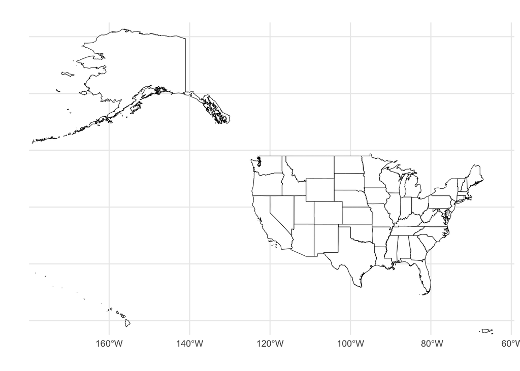

   ```r
   #type of your code/command here.

   us_states <- read_sf("cb_2018_us_state_500k/cb_2018_us_state_500k.shp")

   plot3 <- ggplot() +
     geom_sf(data = us_states, fill = "white", color = "black") +
     coord_sf(xlim = c(-180, -65),
        ylim = c(20, 70)) +
     theme_minimal()

   plot3
   ```

3. Plot the hospital locations using the *LONGITUDE* and *LATITUDE* with `geom_point()` on the USA map generated above. Mark OPEN and CLOSED hospitals using different colors.

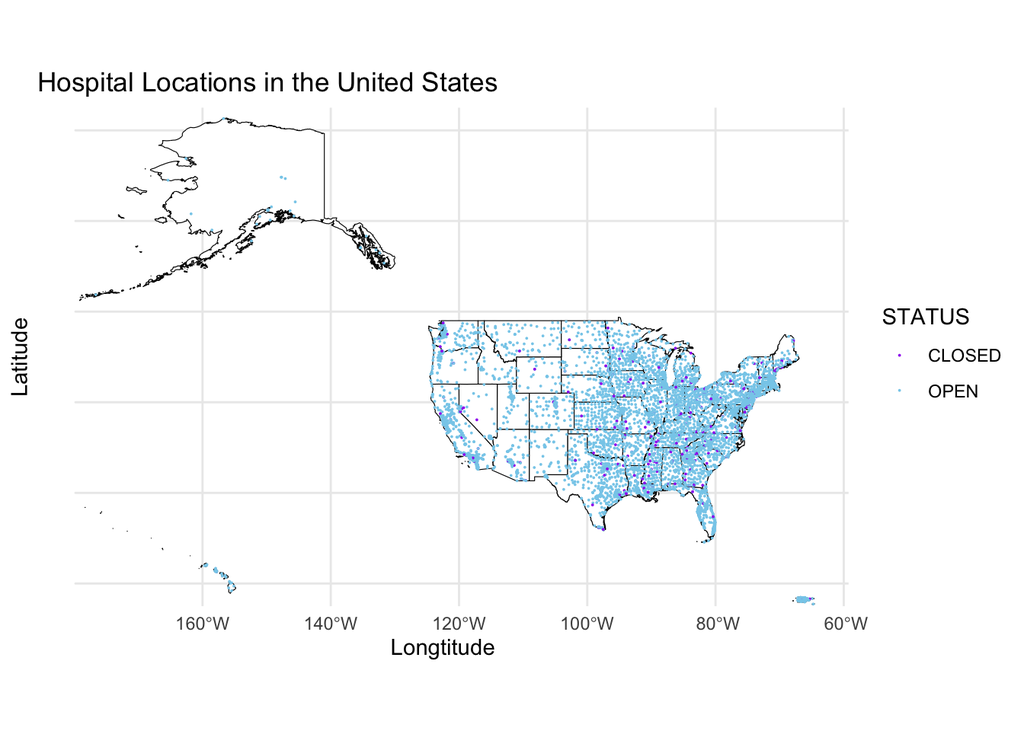

   ```r
   #gg <- ggplot()
   #gg <- gg + geom_sf(data=us_states,
   #                    fill="white", color="black")
   #gg <- gg + geom_point(data=hospital_data, aes(x=LONGITUDE, y=LATITUDE, color=STATUS),
   #                  alpha=1, na.rm=TRUE)
   #gg <- gg + scale_size(range=c(2,7))
   #gg <- gg + scale_color_identity()
   #gg <- gg + scale_color_manual(values = c("OPEN" = "lightgreen", "CLOSED" = "red"),
   #                 name = "Hospital Status",
   #                 labels = c("Open", "Closed")) + labs(color = "Hospital Status") + theme_minimal()
   #gg <- gg + theme(title= element_text(hjust = 1, vjust=1, face="bold"))
   #gg

   plot4 <- plot3 +
         geom_point(data = hospital_data, aes(x = LONGITUDE, y = LATITUDE, color = STATUS), pch = 19, size=0.00005) +
         labs(x = "Longtitude",
              y = "Latitude",
             title = "Hospital Locations in the United States") +
         scale_color_manual(values = c("OPEN" = "skyblue", "CLOSED" = "purple"))   # Specify colors for OPEN and CLOSED


   plot4
   ```

4. Please write a paragraph describing the pattern of the hospital locations you find on the map above.

   **Answer:** The map above displays hospital locations across the United States, with open hospitals marked in skyblue and closed hospitals in purple. Upon examining the pattern of hospital locations, several observations can be made. Firstly, there is a noticeable concentration of hospitals in urban areas, particularly in major cities and metropolitan regions. This concentration aligns with population centers where healthcare demand is typically higher. Additionally, clusters of hospitals are often found along major highways and transportation routes, indicating strategic placement for accessibility and emergency services. In contrast, rural and remote areas show fewer hospital locations, reflecting challenges in healthcare access faced by these communities. The distribution of open and closed hospitals also reveals insights into healthcare infrastructure dynamics, with closures often seen in areas experiencing demographic shifts or economic challenges. Overall, the map offers a glimpse into the spatial distribution of healthcare facilities in the United States, highlighting areas of healthcare accessibility and potential disparities.